# Risk Factor Analysis

## Outcome Variable

**Outcome Variable:** stunted

## Predictor Variables

**Intervention Variable:** birthlen

**Adjustment Set:**

- arm
- sex
- W_mage
- meducyrs
- feducyrs
- vagbrth
- single
- brthmon
- W_parity
- delta_W_mage
- delta_meducyrs
- delta_feducyrs
- delta_vagbrth
- delta_single
- delta_brthmon
- delta_W_parity

## Stratifying Variables

The analysis was stratified on these variable(s):

- agecat
- studyid
- country

## Data Summary

| agecat | studyid | country | birthlen | stunted | n_cell | n |
| --- | --- | --- | --- | --- | --- | --- |
| Birth | ki0047075b-MAL-ED | BANGLADESH | >=50 cm | 0 | 39 | 231 |
| Birth | ki0047075b-MAL-ED | BANGLADESH | >=50 cm | 1 | 0 | 231 |
| Birth | ki0047075b-MAL-ED | BANGLADESH | <48 cm | 0 | 69 | 231 |
| Birth | ki0047075b-MAL-ED | BANGLADESH | <48 cm | 1 | 44 | 231 |
| Birth | ki0047075b-MAL-ED | BANGLADESH | [48-50) cm | 0 | 79 | 231 |
| Birth | ki0047075b-MAL-ED | BANGLADESH | [48-50) cm | 1 | 0 | 231 |
| Birth | ki0047075b-MAL-ED | BRAZIL | >=50 cm | 0 | 30 | 65 |
| Birth | ki0047075b-MAL-ED | BRAZIL | >=50 cm | 1 | 0 | 65 |
| Birth | ki0047075b-MAL-ED | BRAZIL | <48 cm | 0 | 8 | 65 |
| Birth | ki0047075b-MAL-ED | BRAZIL | <48 cm | 1 | 9 | 65 |
| Birth | ki0047075b-MAL-ED | BRAZIL | [48-50) cm | 0 | 18 | 65 |
| Birth | ki0047075b-MAL-ED | BRAZIL | [48-50) cm | 1 | 0 | 65 |
| Birth | ki0047075b-MAL-ED | INDIA | >=50 cm | 0 | 9 | 47 |
| Birth | ki0047075b-MAL-ED | INDIA | >=50 cm | 1 | 0 | 47 |
| Birth | ki0047075b-MAL-ED | INDIA | <48 cm | 0 | 10 | 47 |
| Birth | ki0047075b-MAL-ED | INDIA | <48 cm | 1 | 10 | 47 |
| Birth | ki0047075b-MAL-ED | INDIA | [48-50) cm | 0 | 18 | 47 |
| Birth | ki0047075b-MAL-ED | INDIA | [48-50) cm | 1 | 0 | 47 |
| Birth | ki0047075b-MAL-ED | NEPAL | >=50 cm | 0 | 8 | 27 |
| Birth | ki0047075b-MAL-ED | NEPAL | >=50 cm | 1 | 0 | 27 |
| Birth | ki0047075b-MAL-ED | NEPAL | <48 cm | 0 | 10 | 27 |
| Birth | ki0047075b-MAL-ED | NEPAL | <48 cm | 1 | 2 | 27 |
| Birth | ki0047075b-MAL-ED | NEPAL | [48-50) cm | 0 | 7 | 27 |
| Birth | ki0047075b-MAL-ED | NEPAL | [48-50) cm | 1 | 0 | 27 |
| Birth | ki0047075b-MAL-ED | PERU | >=50 cm | 0 | 52 | 233 |
| Birth | ki0047075b-MAL-ED | PERU | >=50 cm | 1 | 0 | 233 |
| Birth | ki0047075b-MAL-ED | PERU | <48 cm | 0 | 62 | 233 |
| Birth | ki0047075b-MAL-ED | PERU | <48 cm | 1 | 26 | 233 |
| Birth | ki0047075b-MAL-ED | PERU | [48-50) cm | 0 | 93 | 233 |
| Birth | ki0047075b-MAL-ED | PERU | [48-50) cm | 1 | 0 | 233 |

[output cut: 426 more lines]

The following strata were considered:

- agecat: 24 months, studyid: ki0047075b-MAL-ED, country: BANGLADESH
- agecat: 24 months, studyid: ki0047075b-MAL-ED, country: BRAZIL
- agecat: 24 months, studyid: ki0047075b-MAL-ED, country: INDIA
- agecat: 24 months, studyid: ki0047075b-MAL-ED, country: NEPAL
- agecat: 24 months, studyid: ki0047075b-MAL-ED, country: PERU
- agecat: 24 months, studyid: ki0047075b-MAL-ED, country: SOUTH AFRICA
- agecat: 24 months, studyid: ki0047075b-MAL-ED, country: TANZANIA, UNITED REPUBLIC OF
- agecat: 24 months, studyid: ki1000108-CMC-V-BCS-2002, country: INDIA
- agecat: 24 months, studyid: ki1000108-IRC, country: INDIA
- agecat: 24 months, studyid: ki1000109-EE, country: PAKISTAN
- agecat: 24 months, studyid: ki1017093-NIH-Birth, country: BANGLADESH
- agecat: 24 months, studyid: ki1017093b-PROVIDE, country: BANGLADESH
- agecat: 24 months, studyid: ki1017093c-NIH-Crypto, country: BANGLADESH
- agecat: 24 months, studyid: ki1101329-Keneba, country: GAMBIA
- agecat: 24 months, studyid: ki1113344-GMS-Nepal, country: NEPAL
- agecat: 24 months, studyid: ki1114097-CMIN, country: BANGLADESH
- agecat: 24 months, studyid: ki1114097-CONTENT, country: PERU
- agecat: 24 months, studyid: ki1119695-PROBIT, country: BELARUS
- agecat: 24 months, studyid: ki1126311-ZVITAMBO, country: ZIMBABWE
- agecat: 24 months, studyid: ki1135781-COHORTS, country: GUATEMALA
- agecat: 24 months, studyid: ki1135781-COHORTS, country: INDIA
- agecat: 24 months, studyid: ki1135781-COHORTS, country: PHILIPPINES
- agecat: 24 months, studyid: kiGH5241-JiVitA-3, country: BANGLADESH
- agecat: 24 months, studyid: kiGH5241-JiVitA-4, country: BANGLADESH
- agecat: 6 months, studyid: ki0047075b-MAL-ED, country: BANGLADESH
- agecat: 6 months, studyid: ki0047075b-MAL-ED, country: BRAZIL
- agecat: 6 months, studyid: ki0047075b-MAL-ED, country: INDIA
- agecat: 6 months, studyid: ki0047075b-MAL-ED, country: NEPAL
- agecat: 6 months, studyid: ki0047075b-MAL-ED, country: PERU
- agecat: 6 months, studyid: ki0047075b-MAL-ED, country: SOUTH AFRICA
- agecat: 6 months, studyid: ki0047075b-MAL-ED, country: TANZANIA, UNITED REPUBLIC OF
- agecat: 6 months, studyid: ki1000108-CMC-V-BCS-2002, country: INDIA
- agecat: 6 months, studyid: ki1000108-IRC, country: INDIA
- agecat: 6 months, studyid: ki1000109-EE, country: PAKISTAN
- agecat: 6 months, studyid: ki1000109-ResPak, country: PAKISTAN
- agecat: 6 months, studyid: ki1000304b-SAS-CompFeed, country: INDIA
- agecat: 6 months, studyid: ki1017093-NIH-Birth, country: BANGLADESH
- agecat: 6 months, studyid: ki1017093b-PROVIDE, country: BANGLADESH
- agecat: 6 months, studyid: ki1017093c-NIH-Crypto, country: BANGLADESH
- agecat: 6 months, studyid: ki1101329-Keneba, country: GAMBIA
- agecat: 6 months, studyid: ki1113344-GMS-Nepal, country: NEPAL
- agecat: 6 months, studyid: ki1114097-CMIN, country: BANGLADESH
- agecat: 6 months, studyid: ki1114097-CONTENT, country: PERU
- agecat: 6 months, studyid: ki1119695-PROBIT, country: BELARUS
- agecat: 6 months, studyid: ki1126311-ZVITAMBO, country: ZIMBABWE
- agecat: 6 months, studyid: ki1135781-COHORTS, country: GUATEMALA
- agecat: 6 months, studyid: ki1135781-COHORTS, country: INDIA
- agecat: 6 months, studyid: ki1135781-COHORTS, country: PHILIPPINES
- agecat: 6 months, studyid: kiGH5241-JiVitA-3, country: BANGLADESH
- agecat: 6 months, studyid: kiGH5241-JiVitA-4, country: BANGLADESH
- agecat: Birth, studyid: ki0047075b-MAL-ED, country: BANGLADESH
- agecat: Birth, studyid: ki0047075b-MAL-ED, country: BRAZIL
- agecat: Birth, studyid: ki0047075b-MAL-ED, country: INDIA
- agecat: Birth, studyid: ki0047075b-MAL-ED, country: NEPAL
- agecat: Birth, studyid: ki0047075b-MAL-ED, country: PERU
- agecat: Birth, studyid: ki0047075b-MAL-ED, country: SOUTH AFRICA
- agecat: Birth, studyid: ki0047075b-MAL-ED, country: TANZANIA, UNITED REPUBLIC OF
- agecat: Birth, studyid: ki1000108-CMC-V-BCS-2002, country: INDIA
- agecat: Birth, studyid: ki1000108-IRC, country: INDIA
- agecat: Birth, studyid: ki1000109-EE, country: PAKISTAN
- agecat: Birth, studyid: ki1000109-ResPak, country: PAKISTAN
- agecat: Birth, studyid: ki1000304b-SAS-CompFeed, country: INDIA
- agecat: Birth, studyid: ki1017093-NIH-Birth, country: BANGLADESH
- agecat: Birth, studyid: ki1017093b-PROVIDE, country: BANGLADESH
- agecat: Birth, studyid: ki1017093c-NIH-Crypto, country: BANGLADESH
- agecat: Birth, studyid: ki1101329-Keneba, country: GAMBIA
- agecat: Birth, studyid: ki1113344-GMS-Nepal, country: NEPAL
- agecat: Birth, studyid: ki1114097-CMIN, country: BANGLADESH
- agecat: Birth, studyid: ki1114097-CONTENT, country: PERU
- agecat: Birth, studyid: ki1119695-PROBIT, country: BELARUS
- agecat: Birth, studyid: ki1126311-ZVITAMBO, country: ZIMBABWE
- agecat: Birth, studyid: ki1135781-COHORTS, country: GUATEMALA
- agecat: Birth, studyid: ki1135781-COHORTS, country: INDIA
- agecat: Birth, studyid: ki1135781-COHORTS, country: PHILIPPINES
- agecat: Birth, studyid: kiGH5241-JiVitA-3, country: BANGLADESH
- agecat: Birth, studyid: kiGH5241-JiVitA-4, country: BANGLADESH

### Dropped Strata

Some strata were dropped due to rare outcomes:

- agecat: Birth, studyid: ki0047075b-MAL-ED, country: BANGLADESH
- agecat: Birth, studyid: ki0047075b-MAL-ED, country: BRAZIL
- agecat: Birth, studyid: ki0047075b-MAL-ED, country: INDIA
- agecat: Birth, studyid: ki0047075b-MAL-ED, country: NEPAL
- agecat: Birth, studyid: ki0047075b-MAL-ED, country: PERU
- agecat: Birth, studyid: ki0047075b-MAL-ED, country: SOUTH AFRICA
- agecat: Birth, studyid: ki0047075b-MAL-ED, country: TANZANIA, UNITED REPUBLIC OF
- agecat: Birth, studyid: ki1000108-CMC-V-BCS-2002, country: INDIA
- agecat: Birth, studyid: ki1000108-IRC, country: INDIA
- agecat: Birth, studyid: ki1000109-EE, country: PAKISTAN
- agecat: Birth, studyid: ki1000109-ResPak, country: PAKISTAN
- agecat: Birth, studyid: ki1000304b-SAS-CompFeed, country: INDIA
- agecat: Birth, studyid: ki1017093-NIH-Birth, country: BANGLADESH
- agecat: Birth, studyid: ki1017093b-PROVIDE, country: BANGLADESH
- agecat: Birth, studyid: ki1017093c-NIH-Crypto, country: BANGLADESH
- agecat: Birth, studyid: ki1101329-Keneba, country: GAMBIA
- agecat: Birth, studyid: ki1113344-GMS-Nepal, country: NEPAL
- agecat: Birth, studyid: ki1114097-CMIN, country: BANGLADESH
- agecat: Birth, studyid: ki1114097-CONTENT, country: PERU
- agecat: Birth, studyid: ki1119695-PROBIT, country: BELARUS
- agecat: Birth, studyid: ki1126311-ZVITAMBO, country: ZIMBABWE
- agecat: Birth, studyid: ki1135781-COHORTS, country: GUATEMALA
- agecat: Birth, studyid: ki1135781-COHORTS, country: INDIA
- agecat: Birth, studyid: ki1135781-COHORTS, country: PHILIPPINES
- agecat: Birth, studyid: kiGH5241-JiVitA-3, country: BANGLADESH
- agecat: Birth, studyid: kiGH5241-JiVitA-4, country: BANGLADESH
- agecat: 6 months, studyid: ki0047075b-MAL-ED, country: BANGLADESH
- agecat: 6 months, studyid: ki0047075b-MAL-ED, country: BRAZIL
- agecat: 6 months, studyid: ki0047075b-MAL-ED, country: INDIA
- agecat: 6 months, studyid: ki0047075b-MAL-ED, country: NEPAL
- agecat: 6 months, studyid: ki0047075b-MAL-ED, country: PERU
- agecat: 6 months, studyid: ki0047075b-MAL-ED, country: SOUTH AFRICA
- agecat: 6 months, studyid: ki0047075b-MAL-ED, country: TANZANIA, UNITED REPUBLIC OF
- agecat: 6 months, studyid: ki1000109-EE, country: PAKISTAN
- agecat: 6 months, studyid: ki1000109-ResPak, country: PAKISTAN
- agecat: 6 months, studyid: ki1017093b-PROVIDE, country: BANGLADESH
- agecat: 6 months, studyid: ki1017093c-NIH-Crypto, country: BANGLADESH
- agecat: 6 months, studyid: ki1113344-GMS-Nepal, country: NEPAL
- agecat: 6 months, studyid: ki1114097-CMIN, country: BANGLADESH
- agecat: 6 months, studyid: ki1114097-CONTENT, country: PERU
- agecat: 24 months, studyid: ki0047075b-MAL-ED, country: BRAZIL
- agecat: 24 months, studyid: ki0047075b-MAL-ED, country: INDIA
- agecat: 24 months, studyid: ki0047075b-MAL-ED, country: NEPAL
- agecat: 24 months, studyid: ki1000109-EE, country: PAKISTAN
- agecat: 24 months, studyid: ki1114097-CMIN, country: BANGLADESH
- agecat: 24 months, studyid: ki1114097-CONTENT, country: PERU

## Methods Detail

We’re interested in the causal parameters $E[Y_a]$ for all values of $a \in \mathcal{A}$. These parameters represent the mean outcome if, possibly contrary to fact, we intervened to set all units to have $A=a$. Under the randomization and positivity assumptions, these are identified by the statistical parameters $\psi_a=E_W[E_{Y|A,W}(Y|A=a,W)]$. In addition, we’re interested in the mean of $Y$, $E[Y]$ under no intervention (the observed mean). We will estimate these parameters by using SuperLearner to fit the relevant likelihood factors – $E_{Y|A,W}(Y|A=a,W)$ and $p(A=a|W)$, and then updating our likelihood fit using a joint TMLE.

For unadjusted analyses ($W=\{\}$), initial likelihoods were estimated using Lrnr_glm to estimate the simple $E(Y|A)$ and Lrnr_mean to estimate $p(A)$. For adjusted analyses, a small library containing Lrnr_glmnet, Lrnr_xgboost, and Lrnr_mean was used.

Having estimated these parameters, we will then use the delta method to estimate relative risks and attributable risks relative to a prespecified baseline level of $A$.

# Results Detail

## Results Plots

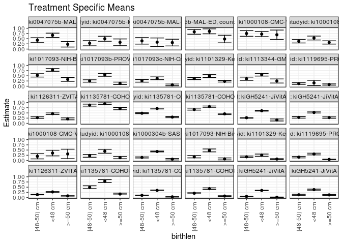

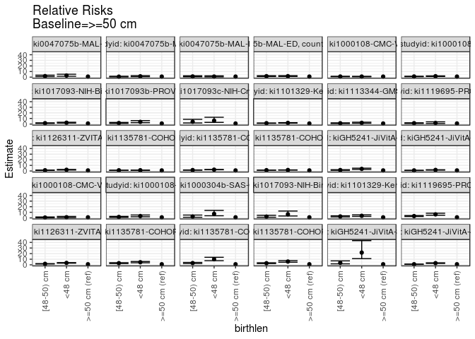

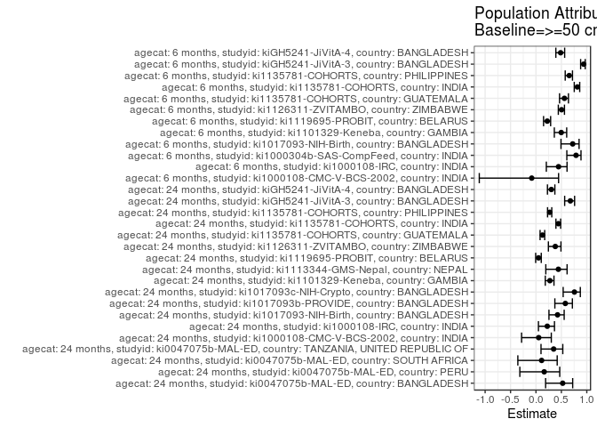

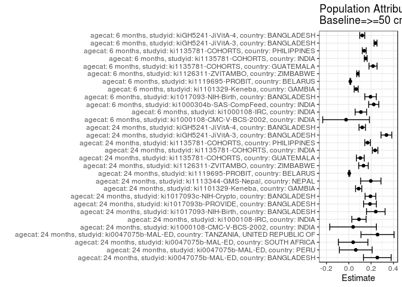

## Results Table

### Parameter: TSM

| agecat | studyid | country | intervention_level | baseline_level | estimate | ci_lower | ci_upper |
| --- | --- | --- | --- | --- | --- | --- | --- |
| 6 months | ki1000108-CMC-V-BCS-2002 | INDIA | >=50 cm | NA | 0.3125000 | 0.0842832 | 0.5407168 |
| 6 months | ki1000108-CMC-V-BCS-2002 | INDIA | <48 cm | NA | 0.3541667 | 0.2182134 | 0.4901199 |
| 6 months | ki1000108-CMC-V-BCS-2002 | INDIA | [48-50) cm | NA | 0.2000000 | 0.0754407 | 0.3245593 |
| 6 months | ki1000108-IRC | INDIA | >=50 cm | NA | 0.1357915 | 0.0805035 | 0.1910796 |
| 6 months | ki1000108-IRC | INDIA | <48 cm | NA | 0.4428387 | 0.3474377 | 0.5382396 |
| 6 months | ki1000108-IRC | INDIA | [48-50) cm | NA | 0.2233918 | 0.1551529 | 0.2916306 |
| 6 months | ki1000304b-SAS-CompFeed | INDIA | >=50 cm | NA | 0.0601029 | 0.0243827 | 0.0958232 |
| 6 months | ki1000304b-SAS-CompFeed | INDIA | <48 cm | NA | 0.4303615 | 0.4101815 | 0.4505416 |
| 6 months | ki1000304b-SAS-CompFeed | INDIA | [48-50) cm | NA | 0.1445683 | 0.1178334 | 0.1713031 |
| 6 months | ki1017093-NIH-Birth | BANGLADESH | >=50 cm | NA | 0.0750000 | 0.0278286 | 0.1221714 |
| 6 months | ki1017093-NIH-Birth | BANGLADESH | <48 cm | NA | 0.4824121 | 0.4129189 | 0.5519053 |
| 6 months | ki1017093-NIH-Birth | BANGLADESH | [48-50) cm | NA | 0.1758794 | 0.1229321 | 0.2288267 |
| 6 months | ki1101329-Keneba | GAMBIA | >=50 cm | NA | 0.0671668 | 0.0480826 | 0.0862510 |
| 6 months | ki1101329-Keneba | GAMBIA | <48 cm | NA | 0.2529516 | 0.1985807 | 0.3073225 |
| 6 months | ki1101329-Keneba | GAMBIA | [48-50) cm | NA | 0.1749092 | 0.1397380 | 0.2100804 |
| 6 months | ki1119695-PROBIT | BELARUS | >=50 cm | NA | 0.0487634 | 0.0350775 | 0.0624494 |
| 6 months | ki1119695-PROBIT | BELARUS | <48 cm | NA | 0.3080294 | 0.2670038 | 0.3490550 |
| 6 months | ki1119695-PROBIT | BELARUS | [48-50) cm | NA | 0.1582741 | 0.1220940 | 0.1944543 |
| 6 months | ki1126311-ZVITAMBO | ZIMBABWE | >=50 cm | NA | 0.0805404 | 0.0698292 | 0.0912515 |
| 6 months | ki1126311-ZVITAMBO | ZIMBABWE | <48 cm | NA | 0.2721430 | 0.2551905 | 0.2890955 |
| 6 months | ki1126311-ZVITAMBO | ZIMBABWE | [48-50) cm | NA | 0.1413211 | 0.1294682 | 0.1531739 |
| 6 months | ki1135781-COHORTS | GUATEMALA | >=50 cm | NA | 0.1707274 | 0.1307961 | 0.2106587 |
| 6 months | ki1135781-COHORTS | GUATEMALA | <48 cm | NA | 0.7919987 | 0.7218242 | 0.8621732 |
| 6 months | ki1135781-COHORTS | GUATEMALA | [48-50) cm | NA | 0.4985342 | 0.4297762 | 0.5672922 |
| 6 months | ki1135781-COHORTS | INDIA | >=50 cm | NA | 0.0345583 | 0.0244224 | 0.0446942 |
| 6 months | ki1135781-COHORTS | INDIA | <48 cm | NA | 0.3450464 | 0.3265133 | 0.3635795 |
| 6 months | ki1135781-COHORTS | INDIA | [48-50) cm | NA | 0.1075318 | 0.0946368 | 0.1204269 |
| 6 months | ki1135781-COHORTS | PHILIPPINES | >=50 cm | NA | 0.0732040 | 0.0568383 | 0.0895698 |
| 6 months | ki1135781-COHORTS | PHILIPPINES | <48 cm | NA | 0.4299710 | 0.3934573 | 0.4664846 |
| 6 months | ki1135781-COHORTS | PHILIPPINES | [48-50) cm | NA | 0.2082346 | 0.1836276 | 0.2328415 |

[output cut: 60 more lines]

### Parameter: E(Y)

| agecat | studyid | country | intervention_level | baseline_level | estimate | ci_lower | ci_upper |
| --- | --- | --- | --- | --- | --- | --- | --- |
| 6 months | ki1000108-CMC-V-BCS-2002 | INDIA | NA | NA | 0.2884615 | 0.2009687 | 0.3759544 |
| 6 months | ki1000108-IRC | INDIA | NA | NA | 0.2442159 | 0.2014677 | 0.2869642 |
| 6 months | ki1000304b-SAS-CompFeed | INDIA | NA | NA | 0.2839879 | 0.2652870 | 0.3026888 |
| 6 months | ki1017093-NIH-Birth | BANGLADESH | NA | NA | 0.2702703 | 0.2319893 | 0.3085512 |
| 6 months | ki1101329-Keneba | GAMBIA | NA | NA | 0.1336303 | 0.1154530 | 0.1518076 |
| 6 months | ki1119695-PROBIT | BELARUS | NA | NA | 0.0626864 | 0.0488489 | 0.0765238 |
| 6 months | ki1126311-ZVITAMBO | ZIMBABWE | NA | NA | 0.1624111 | 0.1546051 | 0.1702171 |
| 6 months | ki1135781-COHORTS | GUATEMALA | NA | NA | 0.3880814 | 0.3516414 | 0.4245214 |
| 6 months | ki1135781-COHORTS | INDIA | NA | NA | 0.1864711 | 0.1767241 | 0.1962180 |
| 6 months | ki1135781-COHORTS | PHILIPPINES | NA | NA | 0.2117734 | 0.1963625 | 0.2271843 |
| 6 months | kiGH5241-JiVitA-3 | BANGLADESH | NA | NA | 0.2554582 | 0.2465868 | 0.2643296 |
| 6 months | kiGH5241-JiVitA-4 | BANGLADESH | NA | NA | 0.2490050 | 0.2328619 | 0.2651480 |
| 24 months | ki0047075b-MAL-ED | BANGLADESH | NA | NA | 0.4866310 | 0.4148009 | 0.5584611 |
| 24 months | ki0047075b-MAL-ED | PERU | NA | NA | 0.3875000 | 0.3117751 | 0.4632249 |
| 24 months | ki0047075b-MAL-ED | SOUTH AFRICA | NA | NA | 0.3516484 | 0.2530008 | 0.4502959 |
| 24 months | ki0047075b-MAL-ED | TANZANIA, UNITED REPUBLIC OF | NA | NA | 0.7403846 | 0.6557158 | 0.8250534 |
| 24 months | ki1000108-CMC-V-BCS-2002 | INDIA | NA | NA | 0.7264151 | 0.6411459 | 0.8116842 |
| 24 months | ki1000108-IRC | INDIA | NA | NA | 0.4102564 | 0.3613763 | 0.4591366 |
| 24 months | ki1017093-NIH-Birth | BANGLADESH | NA | NA | 0.5700483 | 0.5223021 | 0.6177945 |
| 24 months | ki1017093b-PROVIDE | BANGLADESH | NA | NA | 0.3287197 | 0.2903909 | 0.3670485 |
| 24 months | ki1017093c-NIH-Crypto | BANGLADESH | NA | NA | 0.2568093 | 0.2190047 | 0.2946140 |
| 24 months | ki1101329-Keneba | GAMBIA | NA | NA | 0.3239437 | 0.2958244 | 0.3520629 |
| 24 months | ki1113344-GMS-Nepal | NEPAL | NA | NA | 0.4476386 | 0.4034301 | 0.4918471 |
| 24 months | ki1119695-PROBIT | BELARUS | NA | NA | 0.0852540 | 0.0554439 | 0.1150642 |
| 24 months | ki1126311-ZVITAMBO | ZIMBABWE | NA | NA | 0.3463930 | 0.3231291 | 0.3696570 |
| 24 months | ki1135781-COHORTS | GUATEMALA | NA | NA | 0.8107143 | 0.7782403 | 0.8431882 |
| 24 months | ki1135781-COHORTS | INDIA | NA | NA | 0.5350988 | 0.5209252 | 0.5492723 |
| 24 months | ki1135781-COHORTS | PHILIPPINES | NA | NA | 0.6232596 | 0.6040367 | 0.6424826 |
| 24 months | kiGH5241-JiVitA-3 | BANGLADESH | NA | NA | 0.4981904 | 0.4842373 | 0.5121435 |
| 24 months | kiGH5241-JiVitA-4 | BANGLADESH | NA | NA | 0.3982945 | 0.3795521 | 0.4170368 |

### Parameter: RR

| agecat | studyid | country | intervention_level | baseline_level | estimate | ci_lower | ci_upper |
| --- | --- | --- | --- | --- | --- | --- | --- |
| 6 months | ki1000108-CMC-V-BCS-2002 | INDIA | >=50 cm | >=50 cm | 1.0000000 | 1.0000000 | 1.000000 |
| 6 months | ki1000108-CMC-V-BCS-2002 | INDIA | <48 cm | >=50 cm | 1.1333333 | 0.4966487 | 2.586223 |
| 6 months | ki1000108-CMC-V-BCS-2002 | INDIA | [48-50) cm | >=50 cm | 0.6400000 | 0.2451020 | 1.671141 |
| 6 months | ki1000108-IRC | INDIA | >=50 cm | >=50 cm | 1.0000000 | 1.0000000 | 1.000000 |
| 6 months | ki1000108-IRC | INDIA | <48 cm | >=50 cm | 3.2611653 | 2.0521022 | 5.182588 |
| 6 months | ki1000108-IRC | INDIA | [48-50) cm | >=50 cm | 1.6451082 | 0.9900829 | 2.733489 |
| 6 months | ki1000304b-SAS-CompFeed | INDIA | >=50 cm | >=50 cm | 1.0000000 | 1.0000000 | 1.000000 |
| 6 months | ki1000304b-SAS-CompFeed | INDIA | <48 cm | >=50 cm | 7.1604072 | 3.8347754 | 13.370126 |
| 6 months | ki1000304b-SAS-CompFeed | INDIA | [48-50) cm | >=50 cm | 2.4053449 | 1.1378268 | 5.084855 |
| 6 months | ki1017093-NIH-Birth | BANGLADESH | >=50 cm | >=50 cm | 1.0000000 | 1.0000000 | 1.000000 |
| 6 months | ki1017093-NIH-Birth | BANGLADESH | <48 cm | >=50 cm | 6.4321608 | 3.3739117 | 12.262530 |
| 6 months | ki1017093-NIH-Birth | BANGLADESH | [48-50) cm | >=50 cm | 2.3450586 | 1.1676868 | 4.709568 |
| 6 months | ki1101329-Keneba | GAMBIA | >=50 cm | >=50 cm | 1.0000000 | 1.0000000 | 1.000000 |
| 6 months | ki1101329-Keneba | GAMBIA | <48 cm | >=50 cm | 3.7660210 | 2.6385344 | 5.375300 |
| 6 months | ki1101329-Keneba | GAMBIA | [48-50) cm | >=50 cm | 2.6041022 | 1.8396561 | 3.686204 |
| 6 months | ki1119695-PROBIT | BELARUS | >=50 cm | >=50 cm | 1.0000000 | 1.0000000 | 1.000000 |
| 6 months | ki1119695-PROBIT | BELARUS | <48 cm | >=50 cm | 6.3168096 | 4.7923295 | 8.326239 |
| 6 months | ki1119695-PROBIT | BELARUS | [48-50) cm | >=50 cm | 3.2457536 | 2.5072314 | 4.201812 |
| 6 months | ki1126311-ZVITAMBO | ZIMBABWE | >=50 cm | >=50 cm | 1.0000000 | 1.0000000 | 1.000000 |
| 6 months | ki1126311-ZVITAMBO | ZIMBABWE | <48 cm | >=50 cm | 3.3789638 | 2.9178104 | 3.913002 |
| 6 months | ki1126311-ZVITAMBO | ZIMBABWE | [48-50) cm | >=50 cm | 1.7546612 | 1.4995703 | 2.053145 |
| 6 months | ki1135781-COHORTS | GUATEMALA | >=50 cm | >=50 cm | 1.0000000 | 1.0000000 | 1.000000 |
| 6 months | ki1135781-COHORTS | GUATEMALA | <48 cm | >=50 cm | 4.6389668 | 3.6130384 | 5.956209 |
| 6 months | ki1135781-COHORTS | GUATEMALA | [48-50) cm | >=50 cm | 2.9200599 | 2.2267014 | 3.829319 |
| 6 months | ki1135781-COHORTS | INDIA | >=50 cm | >=50 cm | 1.0000000 | 1.0000000 | 1.000000 |
| 6 months | ki1135781-COHORTS | INDIA | <48 cm | >=50 cm | 9.9844639 | 7.4113787 | 13.450874 |
| 6 months | ki1135781-COHORTS | INDIA | [48-50) cm | >=50 cm | 3.1116042 | 2.2671544 | 4.270587 |
| 6 months | ki1135781-COHORTS | PHILIPPINES | >=50 cm | >=50 cm | 1.0000000 | 1.0000000 | 1.000000 |
| 6 months | ki1135781-COHORTS | PHILIPPINES | <48 cm | >=50 cm | 5.8735964 | 4.6276439 | 7.455011 |
| 6 months | ki1135781-COHORTS | PHILIPPINES | [48-50) cm | >=50 cm | 2.8445777 | 2.2110194 | 3.659679 |

[output cut: 60 more lines]

### Parameter: PAR

| agecat | studyid | country | intervention_level | baseline_level | estimate | ci_lower | ci_upper |
| --- | --- | --- | --- | --- | --- | --- | --- |
| 6 months | ki1000108-CMC-V-BCS-2002 | INDIA | >=50 cm | NA | -0.0240385 | -0.2331135 | 0.1850366 |
| 6 months | ki1000108-IRC | INDIA | >=50 cm | NA | 0.1084244 | 0.0570971 | 0.1597517 |
| 6 months | ki1000304b-SAS-CompFeed | INDIA | >=50 cm | NA | 0.2238850 | 0.1786904 | 0.2690795 |
| 6 months | ki1017093-NIH-Birth | BANGLADESH | >=50 cm | NA | 0.1952703 | 0.1436988 | 0.2468418 |
| 6 months | ki1101329-Keneba | GAMBIA | >=50 cm | NA | 0.0664635 | 0.0485972 | 0.0843298 |
| 6 months | ki1119695-PROBIT | BELARUS | >=50 cm | NA | 0.0139229 | 0.0102659 | 0.0175800 |
| 6 months | ki1126311-ZVITAMBO | ZIMBABWE | >=50 cm | NA | 0.0818707 | 0.0714804 | 0.0922611 |
| 6 months | ki1135781-COHORTS | GUATEMALA | >=50 cm | NA | 0.2173540 | 0.1812278 | 0.2534802 |
| 6 months | ki1135781-COHORTS | INDIA | >=50 cm | NA | 0.1519127 | 0.1394859 | 0.1643396 |
| 6 months | ki1135781-COHORTS | PHILIPPINES | >=50 cm | NA | 0.1385694 | 0.1211485 | 0.1559903 |
| 6 months | kiGH5241-JiVitA-3 | BANGLADESH | >=50 cm | NA | 0.2397914 | 0.2265622 | 0.2530205 |
| 6 months | kiGH5241-JiVitA-4 | BANGLADESH | >=50 cm | NA | 0.1207908 | 0.0984810 | 0.1431005 |
| 24 months | ki0047075b-MAL-ED | BANGLADESH | >=50 cm | NA | 0.2558618 | 0.1317402 | 0.3799833 |
| 24 months | ki0047075b-MAL-ED | PERU | >=50 cm | NA | 0.0629403 | -0.0838632 | 0.2097437 |
| 24 months | ki0047075b-MAL-ED | SOUTH AFRICA | >=50 cm | NA | 0.0391484 | -0.0930207 | 0.1713174 |
| 24 months | ki0047075b-MAL-ED | TANZANIA, UNITED REPUBLIC OF | >=50 cm | NA | 0.2576260 | 0.1095014 | 0.4057506 |
| 24 months | ki1000108-CMC-V-BCS-2002 | INDIA | >=50 cm | NA | 0.0389151 | -0.1699483 | 0.2477785 |
| 24 months | ki1000108-IRC | INDIA | >=50 cm | NA | 0.0912651 | 0.0271671 | 0.1553632 |
| 24 months | ki1017093-NIH-Birth | BANGLADESH | >=50 cm | NA | 0.2419854 | 0.1588621 | 0.3251086 |
| 24 months | ki1017093b-PROVIDE | BANGLADESH | >=50 cm | NA | 0.1899829 | 0.1325381 | 0.2474276 |
| 24 months | ki1017093c-NIH-Crypto | BANGLADESH | >=50 cm | NA | 0.1943093 | 0.1462097 | 0.2424089 |
| 24 months | ki1101329-Keneba | GAMBIA | >=50 cm | NA | 0.0887401 | 0.0609868 | 0.1164934 |
| 24 months | ki1113344-GMS-Nepal | NEPAL | >=50 cm | NA | 0.1973911 | 0.1062231 | 0.2885591 |
| 24 months | ki1119695-PROBIT | BELARUS | >=50 cm | NA | 0.0043417 | -0.0002862 | 0.0089697 |
| 24 months | ki1126311-ZVITAMBO | ZIMBABWE | >=50 cm | NA | 0.1317451 | 0.0890233 | 0.1744669 |
| 24 months | ki1135781-COHORTS | GUATEMALA | >=50 cm | NA | 0.1034900 | 0.0682975 | 0.1386824 |
| 24 months | ki1135781-COHORTS | INDIA | >=50 cm | NA | 0.2360375 | 0.2113878 | 0.2606873 |
| 24 months | ki1135781-COHORTS | PHILIPPINES | >=50 cm | NA | 0.1687214 | 0.1436268 | 0.1938160 |
| 24 months | kiGH5241-JiVitA-3 | BANGLADESH | >=50 cm | NA | 0.3371822 | 0.2890428 | 0.3853216 |
| 24 months | kiGH5241-JiVitA-4 | BANGLADESH | >=50 cm | NA | 0.1206103 | 0.0917375 | 0.1494831 |

### Parameter: PAF

| agecat | studyid | country | intervention_level | baseline_level | estimate | ci_lower | ci_upper |
| --- | --- | --- | --- | --- | --- | --- | --- |
| 6 months | ki1000108-CMC-V-BCS-2002 | INDIA | >=50 cm | NA | -0.0833333 | -1.1149548 | 0.4450893 |
| 6 months | ki1000108-IRC | INDIA | >=50 cm | NA | 0.4439694 | 0.2041601 | 0.6115172 |
| 6 months | ki1000304b-SAS-CompFeed | INDIA | >=50 cm | NA | 0.7883609 | 0.6073484 | 0.8859266 |
| 6 months | ki1017093-NIH-Birth | BANGLADESH | >=50 cm | NA | 0.7225000 | 0.4923498 | 0.8483084 |
| 6 months | ki1101329-Keneba | GAMBIA | >=50 cm | NA | 0.4973685 | 0.3612867 | 0.6044572 |
| 6 months | ki1119695-PROBIT | BELARUS | >=50 cm | NA | 0.2221046 | 0.1495216 | 0.2884931 |
| 6 months | ki1126311-ZVITAMBO | ZIMBABWE | >=50 cm | NA | 0.5040957 | 0.4398951 | 0.5609375 |
| 6 months | ki1135781-COHORTS | GUATEMALA | >=50 cm | NA | 0.5600732 | 0.4638710 | 0.6390130 |
| 6 months | ki1135781-COHORTS | INDIA | >=50 cm | NA | 0.8146719 | 0.7532082 | 0.8608280 |
| 6 months | ki1135781-COHORTS | PHILIPPINES | >=50 cm | NA | 0.6543285 | 0.5754408 | 0.7185580 |
| 6 months | kiGH5241-JiVitA-3 | BANGLADESH | >=50 cm | NA | 0.9386717 | 0.8789825 | 0.9689205 |
| 6 months | kiGH5241-JiVitA-4 | BANGLADESH | >=50 cm | NA | 0.4850938 | 0.3911852 | 0.5645171 |
| 24 months | ki0047075b-MAL-ED | BANGLADESH | >=50 cm | NA | 0.5257819 | 0.1900215 | 0.7223595 |
| 24 months | ki0047075b-MAL-ED | PERU | >=50 cm | NA | 0.1624265 | -0.3170748 | 0.4673579 |
| 24 months | ki0047075b-MAL-ED | SOUTH AFRICA | >=50 cm | NA | 0.1113281 | -0.3564367 | 0.4177851 |
| 24 months | ki0047075b-MAL-ED | TANZANIA, UNITED REPUBLIC OF | >=50 cm | NA | 0.3479624 | 0.0994439 | 0.5278994 |
| 24 months | ki1000108-CMC-V-BCS-2002 | INDIA | >=50 cm | NA | 0.0535714 | -0.2827855 | 0.3017328 |
| 24 months | ki1000108-IRC | INDIA | >=50 cm | NA | 0.2224587 | 0.0489141 | 0.3643367 |
| 24 months | ki1017093-NIH-Birth | BANGLADESH | >=50 cm | NA | 0.4244997 | 0.2557535 | 0.5549854 |
| 24 months | ki1017093b-PROVIDE | BANGLADESH | >=50 cm | NA | 0.5779479 | 0.3718332 | 0.7164320 |
| 24 months | ki1017093c-NIH-Crypto | BANGLADESH | >=50 cm | NA | 0.7566288 | 0.5354111 | 0.8725119 |
| 24 months | ki1101329-Keneba | GAMBIA | >=50 cm | NA | 0.2739368 | 0.1835273 | 0.3543351 |
| 24 months | ki1113344-GMS-Nepal | NEPAL | >=50 cm | NA | 0.4409609 | 0.1938582 | 0.6123204 |
| 24 months | ki1119695-PROBIT | BELARUS | >=50 cm | NA | 0.0509269 | -0.0054685 | 0.1041592 |
| 24 months | ki1126311-ZVITAMBO | ZIMBABWE | >=50 cm | NA | 0.3803342 | 0.2445837 | 0.4916900 |
| 24 months | ki1135781-COHORTS | GUATEMALA | >=50 cm | NA | 0.1276528 | 0.0811386 | 0.1718124 |
| 24 months | ki1135781-COHORTS | INDIA | >=50 cm | NA | 0.4411102 | 0.3927040 | 0.4856581 |
| 24 months | ki1135781-COHORTS | PHILIPPINES | >=50 cm | NA | 0.2707081 | 0.2280726 | 0.3109887 |
| 24 months | kiGH5241-JiVitA-3 | BANGLADESH | >=50 cm | NA | 0.6768138 | 0.5647103 | 0.7600465 |
| 24 months | kiGH5241-JiVitA-4 | BANGLADESH | >=50 cm | NA | 0.3028169 | 0.2260388 | 0.3719785 |